# 가장 좋은 불펜 투수는 몇 회에 나와야 하는가?

2018-11-26

## 0. 목차

1. 개요
2. 가장 좋은 투수란 무엇일까?
3. 어떤 이닝이 가장 중요한가?
4. 결론

## 개요

## 1. 개요

## 1. 개요

가장 좋은 불펜 투수는 몇 회에 등판해야 하는가?

## 1. 개요

가장 좋은 불펜 투수는 몇 회에 등판해야 하는가?

1. 가장 좋은 불펜 투수
2. 승리에 있어 가장 중요한 이닝

## 가장 좋은 투수란 무엇일까?

## 2. 가장 좋은 투수란 무엇일까?

## 2. 가장 좋은 투수란 무엇일까?

- 실점을 덜 하는
- 승리 기여도가 높은
- 승계 주자를 덜 불러들이는
- 피안타율이 낮은
- 삼진을 잘 잡는
- 땅볼 유도를 잘 하는
- 홈런을 덜 맞는
- 볼넷을 덜 주는 등..

## 2. 가장 좋은 투수란 무엇일까?

**승리 확률을 높여주는 투수가 가장 좋은 투수가 아닐까?**

## 2. 가장 좋은 투수란 무엇일까?

**주자 상황에 따라 좋은 투수의 기준이 달라질 수도 있지 않을까?**

## 2. 가장 좋은 투수란 무엇일까?

Tom Tango

## 2. 가장 좋은 투수란 무엇일까?

Tom Tango

- LI (Leverage Index)
- WPA (Winning Probability Added)

## 2. 가장 좋은 투수란 무엇일까?

Tom Tango

- LI (Leverage Index)
  - 상황 중요도
  - (승리확률의 변화량을 가중 평균한 값) / (승리확률의 평균 변화량)
  - 마무리 투수 제외, 팀 내 믿음직스럽다고 생각되는 투수가 높을 것
- WPA (Winning Probability Added)
  - 승리 확률 기여도
  - (변화한 승리 확률) - (기존 승리 확률)
  - 이미 벌어진 일에 대한 평가, 수비 영향을 무시

## 2. 가장 좋은 투수란 무엇일까?

상황에 따라 각 투수들의 WPA를 예측한다면 가장 좋은 투수를 알 수 있지 않을까?

## 2. 가장 좋은 투수란 무엇일까?

상황에 따라 각 투수들의 WPA를 예측한다면 가장 좋은 투수를 알 수 있지 않을까?

기준 : Tom Tango의 Win Probability 스프레드 시트 2006/5/4 버전 WE 참고

상황 : 홈팀 7회초 1아웃 만루 1점 리드 시 승률 : 0.511

가정 : 안타, 삼진, 땅볼, 뜬볼에 대한 일반적인 주자상황 변화 가정

## 2. 가장 좋은 투수란 무엇일까?

상황에 따라 각 투수들의 WPA를 예측한다면 가장 좋은 투수를 알 수 있지 않을까?

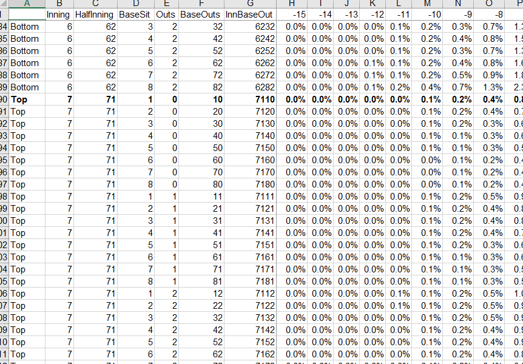

[그림 1: Win Expectancy]

## 2. 가장 좋은 투수란 무엇일까?

상황에 따라 각 투수들의 WPA를 예측한다면 가장 좋은 투수를 알 수 있지 않을까?

(삼진 투수/ 땅볼 투수 / 뜬볼 투수) 기대 WPA를 구해보자 Step.1

삼진투수 : 안타 0.3 삼진 0.7

땅볼투수 : 안타 0.3 땅볼 0.7

뜬볼투수 : 안타 0.3 뜬볼 0.7

## 2. 가장 좋은 투수란 무엇일까?

상황에 따라 각 투수들의 WPA를 예측한다면 가장 좋은 투수를 알 수 있지 않을까?

(삼진 투수/ 땅볼 투수 / 뜬볼 투수) 기대 WPA를 구해보자 Step.2

삼진투수 : 기대 WPA : 0.3 x (0.23-0.511) + 0.7 x (0.651-0.511) = 0.0137

땅볼투수 : 기대 WPA : 0.3 x (0.23-0.511) + 0.7 x (0.749-0.511) = 0.0823

뜬볼투수 : 기대 WPA : 0.3 x (0.23-0.511) + 0.7 x (0.501-0.511) = -0.0913

## 2. 가장 좋은 투수란 무엇일까?

상황에 따라 각 투수들의 WPA를 예측한다면 가장 좋은 투수를 알 수 있지 않을까?

(삼진 투수/ 땅볼 투수 / 뜬볼 투수) 기대 WPA를 구해보자 Step.3

삼진투수 : 평균 WPA 변화율이 0.035일 때 기대 WPA를 나누면 0.3914286

땅볼투수 : 평균 WPA 변화율이 0.035일 때 기대 WPA를 나누면 2.351429

뜬볼투수 : 평균 WPA 변화율이 0.035일 때 기대 WPA를 나누면 -2.608571

## 2. 가장 좋은 투수란 무엇일까?

상황에 따라 각 투수들의 WPA를 예측한다면 가장 좋은 투수를 알 수 있지 않을까?

(삼진 투수/ 땅볼 투수 / 뜬볼 투수) 기대 WPA를 구해보자 Step.3

삼진투수 : 평균 WPA 변화율이 0.035일 때 기대 WPA를 나누면 0.3914286

땅볼투수 : 평균 WPA 변화율이 0.035일 때 기대 WPA를 나누면 2.351429

뜬볼투수 : 평균 WPA 변화율이 0.035일 때 기대 WPA를 나누면 -2.608571

**해당 상황에서는 땅볼투수가 가장 유리!**

## 어떤 이닝이 가장 중요한가?

## 3. 어떤 이닝이 가장 중요한가?

## 3. 어떤 이닝이 가장 중요한가?

[이닝 / 아웃카운트 / 주자상황 / 점수차] 고려한 승리 확률

## 3. 어떤 이닝이 가장 중요한가?

[이닝 / 아웃카운트 / 주자상황 / 점수차] 고려한 승리 확률

- 이미 Tom Tango가 계산

[figure not shown]

[그림 2: Win Expectancy 구글 이미지]

## 3. 어떤 이닝이 가장 중요한가?

타자의 능력이 순수하게 올라가는 이닝은 없을까?

## 3. 어떤 이닝이 가장 중요한가?

타자의 능력이 순수하게 올라가는 이닝은 없을까?

- 우선 이닝별 타율, 출루율, 장타율, 삼진율 확인
- 특별히 성적이 높아지는 때가 있다면 그 근처 이닝에서 승리 확률 계산
- 이닝별로 크게 차이나지 않는다면 Tom Tango의 WE 이용

## 3. 어떤 이닝이 가장 중요한가?

타자의 능력이 순수하게 올라가는 이닝은 없을까?

- MLB 2009 ~ 2018 팬그래프닷컴 자료 이용
- 각 년도 이닝별 AVG, OBP, SLG, K%

```
## 'data.frame':    100 obs. of  5 variables:
##  $ inning: int  1 1 1 1 1 1 1 1 1 1 ...
##  $ AVG   : num  0.269 0.262 0.266 0.266 0.264 ...
##  $ OBP   : num  0.339 0.334 0.329 0.331 0.328 ...
##  $ SLG   : num  0.424 0.402 0.418 0.428 0.411 ...
##  $ K.    : num  0.175 0.176 0.181 0.187 0.19 ...
```

## 3. 어떤 이닝이 가장 중요한가?

타자의 능력이 순수하게 올라가는 이닝은 없을까?

- 독립변수의 정규성 검증

```
## $`1`
##
##  Shapiro-Wilk normality test
##
## data:  X[[i]]
## W = 0.90351, p-value = 0.2393
##
##
## $`2`
##
##  Shapiro-Wilk normality test
##
## data:  X[[i]]
## W = 0.90953, p-value = 0.2778
##
##
## $`3`
##
##  Shapiro-Wilk normality test
##
## data:  X[[i]]
## W = 0.97694, p-value = 0.9467
##
##
## $`4`
##
##  Shapiro-Wilk normality test
##
## data:  X[[i]]
## W = 0.95593, p-value = 0.7386
##
##
## $`5`
##
##  Shapiro-Wilk normality test
##
## data:  X[[i]]
## W = 0.98354, p-value = 0.9813
##
##
```

[output cut: 23 more lines]

```
##
## $`9`
##
##  Shapiro-Wilk normality test
##
## data:  X[[i]]
## W = 0.96813, p-value = 0.873
##
##
## $`10`
##
##  Shapiro-Wilk normality test
##
## data:  X[[i]]
## W = 0.88746, p-value = 0.1588
```

## 3. 어떤 이닝이 가장 중요한가?

타자의 능력이 순수하게 올라가는 이닝은 없을까?

- 독립변수의 등분산성 검증

```
##
##  Bartlett test of homogeneity of variances
##
## data:  AVG by inning
## Bartlett's K-squared = 9.0458, df = 9, p-value = 0.4331
```

## 3. 어떤 이닝이 가장 중요한가?

타자의 능력이 순수하게 올라가는 이닝은 없을까?

```
## Analysis of Variance Table
##
## Response: AVG
##           Df    Sum Sq    Mean Sq F value    Pr(>F)
## inning     1 0.0029443 0.00294431  39.915 7.825e-09 ***
## Residuals 98 0.0072289 0.00007376
## ---
## Signif. codes:  0 '***' 0.001 '**' 0.01 '*' 0.05 '.' 0.1 ' ' 1
```

## 3. 어떤 이닝이 가장 중요한가?

타자의 능력이 순수하게 올라가는 이닝은 없을까?

```
## Analysis of Variance Table
##
## Response: OBP
##           Df   Sum Sq    Mean Sq F value Pr(>F)
## inning     1 0.000149 0.00014903  0.9686 0.3275
## Residuals 98 0.015079 0.00015387
```

## 3. 어떤 이닝이 가장 중요한가?

타자의 능력이 순수하게 올라가는 이닝은 없을까?

```
## Analysis of Variance Table
##
## Response: SLG
##           Df   Sum Sq   Mean Sq F value    Pr(>F)
## inning     1 0.018058 0.0180582  50.338 2.044e-10 ***
## Residuals 98 0.035157 0.0003587
## ---
## Signif. codes:  0 '***' 0.001 '**' 0.01 '*' 0.05 '.' 0.1 ' ' 1
```

## 3. 어떤 이닝이 가장 중요한가?

타자의 능력이 순수하게 올라가는 이닝은 없을까?

```
## Analysis of Variance Table
##
## Response: K.
##           Df   Sum Sq   Mean Sq F value    Pr(>F)
## inning     1 0.007869 0.0078688  22.964 5.875e-06 ***
## Residuals 98 0.033580 0.0003427
## ---
## Signif. codes:  0 '***' 0.001 '**' 0.01 '*' 0.05 '.' 0.1 ' ' 1
```

## 3. 어떤 이닝이 가장 중요한가?

타자의 능력이 순수하게 올라가는 이닝은 없을까?

**이 유의한 차이는 과연 어디서 나오는 것인가?**

## 3. 어떤 이닝이 가장 중요한가?

타자의 능력이 순수하게 올라가는 이닝은 없을까?

- 지표별 평균이 높은 이닝 순서

```r
mAVG <- tapply(inning$AVG, inning$inning, mean)
sort(mAVG, decreasing = T)
```

```
##         1         4         6         5         3        10         7
## 0.2640466 0.2637418 0.2620639 0.2612710 0.2567390 0.2513512 0.2510709
##         2         8         9
## 0.2492235 0.2435229 0.2357735
```

## 3. 어떤 이닝이 가장 중요한가?

타자의 능력이 순수하게 올라가는 이닝은 없을까?

- 지표별 평균이 높은 이닝 순서

```r
mOBP <- tapply(inning$OBP, inning$inning, mean)
sort(mOBP, decreasing = T)
```

```
##        10         1         6         4         5         7         3
## 0.3461987 0.3306614 0.3268445 0.3259810 0.3241259 0.3211014 0.3196258
##         8         2         9
## 0.3158456 0.3107776 0.3052225
```

## 3. 어떤 이닝이 가장 중요한가?

타자의 능력이 순수하게 올라가는 이닝은 없을까?

- 지표별 평균이 높은 이닝 순서

```r
mSLG <- tapply(inning$SLG, inning$inning, mean)
sort(mSLG, decreasing = T)
```

```
##         4         6         1         5         3         2         7
## 0.4298877 0.4239283 0.4238668 0.4199708 0.4055107 0.3993159 0.3972550
##        10         8         9
## 0.3837218 0.3821206 0.3707782
```

## 3. 어떤 이닝이 가장 중요한가?

타자의 능력이 순수하게 올라가는 이닝은 없을까?

- 지표별 평균이 높은 이닝 순서

```r
mK. <- tapply(inning$K., inning$inning, mean)
sort(mK., decreasing = T)
```

```
##         9         8         2        10         7         1         3
## 0.2355506 0.2179282 0.2083451 0.2075057 0.2041003 0.1925575 0.1911200
##         6         4         5
## 0.1886324 0.1883025 0.1854620
```

## 3. 어떤 이닝이 가장 중요한가?

타자의 능력이 순수하게 올라가는 이닝은 없을까?

- 지표별 평균이 높은 이닝 순서

```r
mK. <- tapply(inning$K., inning$inning, mean)
sort(mK., decreasing = T)
```

```
##         9         8         2        10         7         1         3
## 0.2355506 0.2179282 0.2083451 0.2075057 0.2041003 0.1925575 0.1911200
##         6         4         5
## 0.1886324 0.1883025 0.1854620
```

**1, 4, 6, 5에 주목!**

## 3. 어떤 이닝이 가장 중요한가?

타자의 능력이 순수하게 올라가는 이닝은 없을까?

- http://www.newstof.com/news/articleView.html?idxno=646
- 기사에 따르면, 2017년 기준 메이저리그 한 경기 평균 타석은 약 76타석
- 팀당 38타석, 이닝당 4.2타석
- 4이닝, 6이닝은 보통 3번타자를 중심으로 타선이 시작 됨 (장타율 앞서는 이유)
- 타순의 영향을 받는다고 볼 수 있음

## 3. 어떤 이닝이 가장 중요한가?

**따라서, 특별하게 타자의 능력이 오르는 이닝은 없는 것으로 보인다!**

## 3. 어떤 이닝이 가장 중요한가?

**Tom Tango의 WE를 참고, 승률을 가장 높일 수 있는 이닝이 중요!**

## 결론

## 4. 결론

## 4. 결론

1. 이닝, 아웃 상황, 주자 상황, 점수차 -> 등판 투수 결정

## 4. 결론

1. 이닝, 아웃 상황, 주자 상황, 점수차 -> 등판 투수 결정
2. 가장 중요한 이닝은 9회 이전 위기 상황 (합리적 판단 필요)

## 4. 결론

**<예시> 어웨이팀, 5회말 2아웃 만루 1점 리드 승리확률 49.73%**

**당신은 어떤 투수? (통산 성적)**

- WPA : 홈런 시 -0.3885, 그 외 안타 시 -0.2144, 볼넷 시 -0.1374, 아웃 시 0.1595
- A : 홈런 0.026, 그 외 안타 0.224, 볼넷 0.061, 아웃 0.689
- B : 홈런 0.025, 그 외 안타 0.224, 볼넷 0.069, 아웃 0.682
- C : 홈런 0.033, 그 외 안타 0.200, 볼넷 0.070, 아웃 0.697